```python
import numpy as np
import matplotlib.pyplot as plt
from sklearn.metrics import confusion_matrix
import seaborn as sns

%matplotlib inline
```

# Sound classification with deep learning

Our goal is to classify the spoken digits from the [AudioMNIST Dataset](https://www.kaggle.com/datasets/alanchn31/free-spoken-digits). The training set contains 2400 samples with 900 Mel Frequency Cepstrum coefficients each. We will use these 900 coefficients as the features to train on.  
Below is a visualisation of what each of these samples look like as an image.

```python
audio_mnist_training_mfccs = np.genfromtxt('AudioMNIST/MFCC/Training/training_mfccs.txt')
audio_mnist_training_labels = np.genfromtxt('AudioMNIST/MFCC/Training/training_labels.txt').reshape(-1,1)

audio_mnist_testing_mfccs = np.genfromtxt('AudioMNIST/MFCC/Testing/testing_mfccs.txt')
audio_mnist_testing_labels = np.genfromtxt('AudioMNIST/MFCC/Testing/testing_labels.txt').reshape(-1,1)
```

```
<function matplotlib.pyplot.tight_layout(*, pad=1.08, h_pad=None, w_pad=None, rect=None)>
```

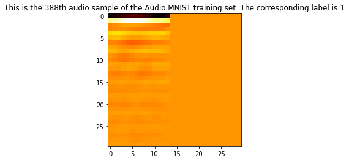

```python
item_number = np.random.randint(low=0, high=2400)

plt.imshow(audio_mnist_training_mfccs[item_number].reshape(30, 30), cmap='hot')
plt.title("This is the {n}th audio sample of the Audio MNIST training set. The corresponding label is {l}".format( \
            n= item_number, l=int(audio_mnist_training_labels[item_number][0])))
plt.tight_layout
```

We implement a neural network from scratch, using an architecture of only two densely connected layers. Below are all the classes and functions we will need to train the network.

```python
class Layer():
    def __init__(self):
        self.input = input
        self.output = output
    def forward(self, input):
        pass
    def backward(self, output_gradient, learning_rate):
        pass

class Dense(Layer):
    def __init__(self, input_size, output_size):
        self.weights = np.random.randn(output_size, input_size)
        self.bias = np.random.randn(output_size, 1)
    def forward(self, input):
        self.input = input
        return np.dot(self.weights, self.input) + self.bias

    def backward(self, output_gradient, learning_rate):
        weights_gradient = np.dot(output_gradient, self.input.T)
        self.weights -= learning_rate * weights_gradient
        self.bias -= learning_rate * output_gradient
        return np.dot(self.weights.T, output_gradient)

###

class Activation(Layer):
    def __init__(self, activation, activation_prime):
        self.activation = activation
        self.activation_prime = activation_prime
    def forward(self, input):
        self.input = input
        return self.activation(self.input)
    def backward(self, output_gradient, learning_rate):
        return np.multiply(output_gradient, self.activation_prime(self.input))

class Sigmoid(Activation):
    def __init__(self):
        def sigmoid(x):
            return 1 / (1 + np.exp(-x))
        def sigmoid_prime(x):
            s = sigmoid(x)
            return s * (1 - s)
        super().__init__(sigmoid, sigmoid_prime)


###


def mse(y_true, y_pred):
    return np.mean(np.power(y_true - y_pred, 2))

def mse_prime(y_true, y_pred):
    return 2 * (y_pred - y_true) / np.size(y_true)


###


def predict(network, input):
    output = input
    for layer in network:
        output = layer.forward(output)
    return output

def train(network,
          loss,
          loss_prime,
          x_train,
          y_train,
          batch_size=None,
          epochs = 1000,
          learning_rate = 0.01,
          verbose = True,
          print_output=10):
    print('Training...')
    if batch_size==None:
        batch_size = len(x_train)
    if not verbose:
        print('Thinking... beep boop')
    for e in range(epochs):
        error = 0
        p = np.random.permutation(batch_size)
        for x, y in zip(x_train[p], y_train[p]):
            # forward
            output = predict(network, x)

            # error
            if batch_size == None:
                error += loss(y, output)
            else:
                error += (len(x_train)//batch_size) * loss(y, output)

            # backward
            grad = loss_prime(y, output)
            for layer in reversed(network):
                grad = layer.backward(grad, learning_rate)

        error /= len(x_train)
        if verbose and (e+1) % print_output == 0:
            print(f"{e + 1}/{epochs}, error={error}")

    return network

def one_hot_vector_encoding(labels):
    labels = labels.astype(int)
    no_of_classes = np.max(labels) + 1
    output = np.zeros((len(labels), no_of_classes))
    output[np.arange(len(labels)), labels] = 1
    return output

def preprocess_data(x, y):
    p = np.random.permutation(len(x))
    x = x[p]
    y = y[p]
    x = x.reshape(x.shape[0], 30 * 30, 1)
    x = x.astype("float32") / 255
    y = one_hot_vector_encoding(y)
    y = y.reshape(y.shape[0], 10, 1)
    return x, y

def classification_accuracy(true_labels, recovered_labels):
    count = 0
    for i, item in enumerate(true_labels):
        if item==recovered_labels[i]:
            count += 1
    return count/len(true_labels)
```

We now train the network for 20 epochs over a range of learning rates. As we do not have a validation set for this data, we validate on training accuracy.

```python
import pandas as pd
np.random.seed(210711042)

audio_mnist_training_mfccs = np.genfromtxt('AudioMNIST/MFCC/Training/training_mfccs.txt')
audio_mnist_training_labels = np.genfromtxt('AudioMNIST/MFCC/Training/training_labels.txt')

audio_mnist_testing_mfccs = np.genfromtxt('AudioMNIST/MFCC/Testing/testing_mfccs.txt')
audio_mnist_testing_labels = np.genfromtxt('AudioMNIST/MFCC/Testing/testing_labels.txt')

x_train, y_train = preprocess_data(audio_mnist_training_mfccs, audio_mnist_training_labels)
x_test, y_test = preprocess_data(audio_mnist_testing_mfccs, audio_mnist_testing_labels)


# neural network
network = [
    Dense(30 * 30, 40),
    Sigmoid(),
    Dense(40, 10),
    Sigmoid()
]

### iterate below to test for effect of learning rate on validation/test error.

nn_val_accuracies = []
nn_test_accuracies = []
l_range = np.linspace(0.01, 2, 10)

for l in l_range:
    print(f'Learning Rate = {l}')
    # train
    model = train(network, mse, mse_prime, x_train, y_train, batch_size=None, epochs=20, learning_rate=l, print_output=20, verbose=True)

    # validate
    y_train_pred = []
    for x, y in zip(x_train, y_train):
        output = predict(network, x)
        y_train_pred.append(np.argmax(output))
    nn_val_accuracies.append(classification_accuracy([np.argmax(y) for y in y_train], y_train_pred))

    # test
    y_test_pred = []
    for x, y in zip(x_test, y_test):
        output = predict(network, x)
        y_test_pred.append(np.argmax(output))
        #print('pred:', np.argmax(output), '\ttrue:', np.argmax(y))
    nn_test_accuracies.append(classification_accuracy([np.argmax(y) for y in y_test], y_test_pred))
print('Done.')
```

```
Learning Rate = 0.01
Training...
20/20, error=0.09340107941154037
Learning Rate = 0.23111111111111113
Training...
20/20, error=0.04788714308176815
Learning Rate = 0.45222222222222225
Training...
20/20, error=0.01958777912021465
Learning Rate = 0.6733333333333333
Training...
20/20, error=0.01065429215562957
Learning Rate = 0.8944444444444445
Training...
20/20, error=0.007902229471752807
Learning Rate = 1.1155555555555556
Training...
20/20, error=0.0072829541324684575
Learning Rate = 1.3366666666666667
Training...
20/20, error=0.005675824243068701
Learning Rate = 1.557777777777778
Training...
20/20, error=0.0047207657416331655
Learning Rate = 1.778888888888889
Training...
20/20, error=0.007156059678047401
Learning Rate = 2.0
Training...
20/20, error=0.006968689784519685
Done.
```

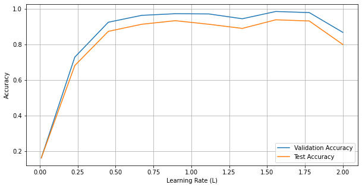

```python
plt.figure(figsize=(10,5))
plt.plot(l_range, nn_val_accuracies, label = 'Validation Accuracy')
plt.plot(l_range, nn_test_accuracies, label = 'Test Accuracy')
plt.grid()
plt.legend()
plt.xlabel('Learning Rate (L)')
plt.ylabel('Accuracy')
plt.savefig('val_test_l_rate_precise.png')
plt.show()
```

```python
optimum_l = l_range[np.argmax(nn_test_accuracies)]
print(f'Optimum learning rate is: {optimum_l:.2f}, with test accuracy: {max(nn_test_accuracies):.2f}')
```

```
Optimum learning rate is: 1.56, with test accuracy: 0.94
```

We now train with 100 epochs on the optimum learning rate to see if this improves accuracy.

```
Training...
10/100, error=0.0032168093390167237
20/100, error=0.002505579540439619
30/100, error=0.0018586508495502334
40/100, error=0.001546325349610625
50/100, error=0.001314164205826172
60/100, error=0.0012644028201468514
70/100, error=0.0008443316017970302
80/100, error=0.0008023117199280373
90/100, error=0.0007641827193966758
100/100, error=0.0008039309614834198
```

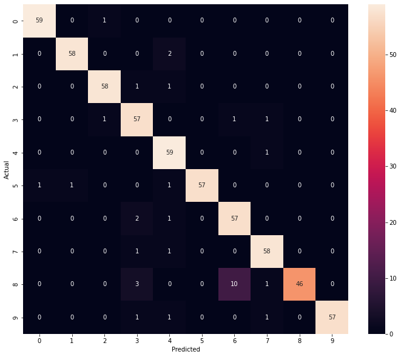

```
Clasification Accuracy: 94.33333333333334 %
```

```python
np.random.seed(210711042)

# train
model = train(network, mse, mse_prime, x_train, y_train, batch_size=None, epochs=100, learning_rate=optimum_l, verbose=True)

# validate
y_train_pred = []
for x, y in zip(x_train, y_train):
    output = predict(network, x)
    y_train_pred.append(np.argmax(output))

# test
y_test_pred = []
for x, y in zip(x_test, y_test):
    output = predict(network, x)
    y_test_pred.append(np.argmax(output))

cm = confusion_matrix([np.argmax(y) for y in y_test], y_test_pred, labels=np.arange(10))
df_cm = pd.DataFrame(cm, index = [i for i in range(10)], columns = [i for i in range(10)])
plt.figure(figsize=(12,10))
sns.heatmap(df_cm, annot=True)
plt.xlabel('Predicted')
plt.ylabel('Actual')
plt.savefig('confusion_matrix_1_1000.png')
plt.show()

nn_accuracy = classification_accuracy([np.argmax(y) for y in y_test], y_test_pred)
print(f'Clasification Accuracy: {100 * nn_accuracy} %')
```

Our neural network appears to struggle with differentiating 8's from 6's, but apart from this is extremely accurate. Perhaps normalising data, adding more layers, involving convolutional layers etc. could improve this.